# US Presidential Election Classification Project

Hei Ting Lam

2022-07-27

Can we train and predict US counties’ presidential election outcome based on some demographics attributes? This project shows that we can do so. Welcome to follow the journey below.

County presidential election result downloaded from https://www.kaggle.com/datasets/unanimad/us-election-2020?select=president_county.csv Data cleaning are done (i.e. only democrats and republicans data are left) for simplicity purpose.

County demographics attributes data downloaded from https://www.ers.usda.gov/data-products/county-level-data-sets/download-data/ Data cleaning (i.e. remove unnecessary column) are done to ensure R would be able to read data.

#1. Load Required packages and data

```r
#install.packages('caret')
library(caret)
#install.packages('caTools')
library(caTools)
#install.packages('MASS')
library(MASS)
```

```r
#install.packages('randomForest')
library(randomForest)
#install.packages('adabag)
library(adabag)
#install.packages('ada')
library(ada)
#install.packages('xgboost')
library(xgboost)
#install.packages('neuralnet')
library(neuralnet)
#install.packages('e1071')
library(e1071)
#install.packages('class')
library(class)
```

```r
#install.packages('rpart')
library(rpart)
#install.packages('rpart.plot')
library(rpart.plot)
```

##1.1 Load election outcome data

```r
df_election_outcome<-read.csv('president_county_candidate.csv',header=TRUE,sep=',')
head(df_election_outcome)
```

```
##                  state               county    candidate party total_votes  won
## 1             Delaware          Kent County    Joe Biden   DEM       44552 TRUE
## 2             Delaware    New Castle County    Joe Biden   DEM      195034 TRUE
## 3             Delaware        Sussex County Donald Trump   REP       71230 TRUE
## 4 District of Columbia District of Columbia    Joe Biden   DEM       39041 TRUE
## 5 District of Columbia               Ward 2    Joe Biden   DEM       29078 TRUE
## 6 District of Columbia               Ward 3    Joe Biden   DEM       39397 TRUE
##   Vote_Share_Of_Each_Party Vote_Share_Scale_.0.Dem.1.Rep.
## 1              0.520704527                    0.479295473
## 2              0.688198223                    0.311801777
## 3              0.556867221                    0.556867221
## 4              0.957685326                    0.042314674
## 5                0.9088011                      0.0911989
## 6              0.914041112                    0.085958888
```

##1.2 Load county education, poverty, unemployment, population data

```r
#install.packages('readxl')
library(readxl)
df_edu<-read_xlsx('Education.xlsx')
df_poverty<-read_xlsx('PovertyEstimates.xlsx')
df_unemployment<-read_xlsx('Unemployment.xlsx')
df_pop<-read_xlsx('PopulationEstimates.xlsx')
head(df_edu)
```

```
## # A tibble: 6 × 55
##   FIPS_code State `Area name` `2003 Rural-Ub…` `2003 Urban In…` `2013 Rural-Ur…`
##   <chr>     <chr> <chr>                  <dbl>            <dbl>            <dbl>
## 1 00000     US    United Sta…               NA               NA               NA
## 2 01000     AL    Alabama                   NA               NA               NA
## 3 01001     AL    Autauga Co…                2                2                2
## 4 01003     AL    Baldwin Co…                4                5                3
## 5 01005     AL    Barbour Co…                6                6                6
## 6 01007     AL    Bibb County                1                1                1
## # … with 49 more variables: `2013 Urban Influence Code` <dbl>,
## #   `Less than a high school diploma, 1970` <dbl>,
## #   `High school diploma only, 1970` <dbl>,
## #   `Some college (1-3 years), 1970` <dbl>,
## #   `Four years of college or higher, 1970` <dbl>,
## #   `Percent of adults with less than a high school diploma, 1970` <dbl>,
## #   `Percent of adults with a high school diploma only, 1970` <dbl>, …
```

```r
head(df_poverty)
```

```
## # A tibble: 6 × 34
##   FIPS_code Stabr Area_name   `Rural-urban_C…` Urban_Influence… `Rural-urban_C…`
##   <chr>     <chr> <chr>                  <dbl>            <dbl>            <dbl>
## 1 00000     US    United Sta…               NA               NA               NA
## 2 01000     AL    Alabama                   NA               NA               NA
## 3 01001     AL    Autauga Co…                2                2                2
## 4 01003     AL    Baldwin Co…                4                5                3
## 5 01005     AL    Barbour Co…                6                6                6
## 6 01007     AL    Bibb County                1                1                1
## # … with 28 more variables: Urban_Influence_Code_2013 <dbl>, POVALL_2020 <dbl>,
## #   CI90LBALL_2020 <dbl>, CI90UBALL_2020 <dbl>, PCTPOVALL_2020 <dbl>,
## #   CI90LBALLP_2020 <dbl>, CI90UBALLP_2020 <dbl>, POV017_2020 <dbl>,
## #   CI90LB017_2020 <dbl>, CI90UB017_2020 <dbl>, PCTPOV017_2020 <dbl>,
## #   CI90LB017P_2020 <dbl>, CI90UB017P_2020 <dbl>, POV517_2020 <dbl>,
## #   CI90LB517_2020 <dbl>, CI90UB517_2020 <dbl>, PCTPOV517_2020 <dbl>,
## #   CI90LB517P_2020 <dbl>, CI90UB517P_2020 <dbl>, MEDHHINC_2020 <dbl>, …
```

```r
head(df_unemployment)
```

```
## # A tibble: 6 × 96
##   FIPS_code State Area_name      Rural_urban_contin… Urban_influence… Metro_2013
##   <chr>     <chr> <chr>                        <dbl>            <dbl>      <dbl>
## 1 00000     US    United States                   NA               NA         NA
## 2 01000     AL    Alabama                         NA               NA         NA
## 3 01001     AL    Autauga County                   2                2          1
## 4 01003     AL    Baldwin County                   3                2          1
## 5 01005     AL    Barbour County                   6                6          0
## 6 01007     AL    Bibb County                      1                1          1
## # … with 90 more variables: Civilian_labor_force_2000 <dbl>,
## #   Employed_2000 <dbl>, Unemployed_2000 <dbl>, Unemployment_rate_2000 <dbl>,
## #   Civilian_labor_force_2001 <dbl>, Employed_2001 <dbl>,
## #   Unemployed_2001 <dbl>, Unemployment_rate_2001 <dbl>,
## #   Civilian_labor_force_2002 <dbl>, Employed_2002 <dbl>,
## #   Unemployed_2002 <dbl>, Unemployment_rate_2002 <dbl>,
## #   Civilian_labor_force_2003 <dbl>, Employed_2003 <dbl>, …
```

```r
head(df_pop)
```

```
## # A tibble: 6 × 9
##   FIPS_code State `Area name` `Rural-Urban C…` `Population 19…` `Population 20…`
##   <chr>     <chr> <chr>                  <dbl>            <dbl>            <dbl>
## 1 00000     US    United Sta…               NA        248790925        281424600
## 2 01000     AL    Alabama                   NA          4040389          4447207
## 3 01001     AL    Autauga Co…                2            34222            43751
## 4 01003     AL    Baldwin Co…                3            98280           140416
## 5 01005     AL    Barbour Co…                6            25417            29042
## 6 01007     AL    Bibb County                1            16598            19856
## # … with 3 more variables: `Population 2010` <dbl>, `Population 2020` <dbl>,
## #   `Population 2021` <dbl>
```

##1.2.1 clear unnecessary columns of education data

```r
df_edu<-df_edu[,c(1:3,6:7,52:55)]
head(df_edu)
```

```
## # A tibble: 6 × 9
##   FIPS_code State `Area name` `2013 Rural-Ur…` `2013 Urban In…` `Percent of ad…`
##   <chr>     <chr> <chr>                  <dbl>            <dbl>            <dbl>
## 1 00000     US    United Sta…               NA               NA            11.5
## 2 01000     AL    Alabama                   NA               NA            13.1
## 3 01001     AL    Autauga Co…                2                2            11.3
## 4 01003     AL    Baldwin Co…                3                2             9.53
## 5 01005     AL    Barbour Co…                6                6            25.3
## 6 01007     AL    Bibb County                1                1            19.1
## # … with 3 more variables:
## #   `Percent of adults with a high school diploma only, 2016-20` <dbl>,
## #   `Percent of adults completing some college or associate's degree, 2016-20` <dbl>,
## #   `Percent of adults with a bachelor's degree or higher 2016-20` <dbl>
```

##1.2.2 clear unnecessary columns of poverty data

```r
df_poverty<-df_poverty[,c(1:3,6:7,11,26)]
head(df_poverty)
```

```
## # A tibble: 6 × 7
##   FIPS_code Stabr Area_name     `Rural-urban_C…` Urban_Influence… PCTPOVALL_2020
##   <chr>     <chr> <chr>                    <dbl>            <dbl>          <dbl>
## 1 00000     US    United States               NA               NA           11.9
## 2 01000     AL    Alabama                     NA               NA           14.9
## 3 01001     AL    Autauga Coun…                2                2           11.2
## 4 01003     AL    Baldwin Coun…                3                2            8.9
## 5 01005     AL    Barbour Coun…                6                6           25.5
## 6 01007     AL    Bibb County                  1                1           17.8
## # … with 1 more variable: MEDHHINC_2020 <dbl>
```

##1.2.3 clear unnecessary columns of unemployment data

```r
df_unemployment<-df_unemployment[,c(1:3,4:6,90)]
head(df_unemployment)
```

```
## # A tibble: 6 × 7
##   FIPS_code State Area_name      Rural_urban_contin… Urban_influence… Metro_2013
##   <chr>     <chr> <chr>                        <dbl>            <dbl>      <dbl>
## 1 00000     US    United States                   NA               NA         NA
## 2 01000     AL    Alabama                         NA               NA         NA
## 3 01001     AL    Autauga County                   2                2          1
## 4 01003     AL    Baldwin County                   3                2          1
## 5 01005     AL    Barbour County                   6                6          0
## 6 01007     AL    Bibb County                      1                1          1
## # … with 1 more variable: Unemployment_rate_2020 <dbl>
```

##1.2.4 clear unnecessary columns of population data

```r
df_pop<-df_pop[,c(1:4,8)]
head(df_pop)
```

```
## # A tibble: 6 × 5
##   FIPS_code State `Area name`    `Rural-Urban Continuum Code …` `Population 20…`
##   <chr>     <chr> <chr>                                   <dbl>            <dbl>
## 1 00000     US    United States                              NA        331449281
## 2 01000     AL    Alabama                                    NA          5024279
## 3 01001     AL    Autauga County                              2            58805
## 4 01003     AL    Baldwin County                              3           231767
## 5 01005     AL    Barbour County                              6            25223
## 6 01007     AL    Bibb County                                 1            22293
```

```r
#install.packages('sqldf')
library(sqldf)
```

##1.3 merge county education, poverty, unemployment, population data

```r
df<-sqldf('SELECT * FROM df_edu JOIN df_poverty ON df_edu.FIPS_code=df_poverty.FIPS_code JOIN df_unemployment ON df_poverty.FIPS_code=df_unemployment.FIPS_code JOIN df_pop on df_unemployment.FIPS_code=df_pop.FIPS_code')
df<-df[,-c(1,4:5,10:14,17:21,24:27)]
head(df)
```

```
##   State      Area name
## 1    US  United States
## 2    AL        Alabama
## 3    AL Autauga County
## 4    AL Baldwin County
## 5    AL Barbour County
## 6    AL    Bibb County
##   Percent of adults with less than a high school diploma, 2016-20
## 1                                                       11.471478
## 2                                                       13.126382
## 3                                                       11.286318
## 4                                                        9.528615
## 5                                                       25.268303
## 6                                                       19.115532
##   Percent of adults with a high school diploma only, 2016-20
```

[output cut: 27 more lines]

##1.3.1 rename states column to the format of election outcome data

```r
df$State[df$State=='AL']<-'Alabama'
df$State[df$State=='AK']<-'Alaska'
df$State[df$State=='AR']<-'Arkansas'
df$State[df$State=='AZ']<-'Arizona'
df$State[df$State=='CA']<-'California'
df$State[df$State=='CO']<-'Colorado'
df$State[df$State=='CT']<-'Connecticut'
df$State[df$State=='DC']<-'District of Columbia'
df$State[df$State=='DE']<-'Delaware'
df$State[df$State=='FL']<-'Florida'
df$State[df$State=='GA']<-'Georgia'
df$State[df$State=='HI']<-'Hawaii'
df$State[df$State=='IA']<-'Iowa'
df$State[df$State=='ID']<-'Idaho'
df$State[df$State=='IL']<-'Illinois'
df$State[df$State=='IN']<-'Indiana'
df$State[df$State=='KS']<-'Kansas'
df$State[df$State=='KY']<-'Kentucky'
df$State[df$State=='LA']<-'Louisiana'
df$State[df$State=='MA']<-'Massachusetts'
df$State[df$State=='MD']<-'Maryland'
df$State[df$State=='ME']<-'Maine'
df$State[df$State=='MI']<-'Michigan'
df$State[df$State=='MN']<-'Minnesota'
df$State[df$State=='MO']<-'Missouri'
df$State[df$State=='MS']<-'Mississippi'
df$State[df$State=='MT']<-'Montana'
df$State[df$State=='NC']<-'North Carolina'
df$State[df$State=='ND']<-'North Dakota'
df$State[df$State=='NE']<-'Nebraska'
df$State[df$State=='NH']<-'New Hampshire'
df$State[df$State=='NJ']<-'New Jersey'
df$State[df$State=='NM']<-'New Mexico'
df$State[df$State=='NV']<-'Nevada'
df$State[df$State=='NY']<-'New York'
df$State[df$State=='OH']<-'Ohio'
df$State[df$State=='OK']<-'Oklahoma'
df$State[df$State=='OR']<-'Oregon'
df$State[df$State=='PA']<-'Pennsylvania'
df$State[df$State=='PR']<-'Puerto Rico'
df$State[df$State=='RI']<-'Rhode Island'
df$State[df$State=='SC']<-'South Carolina'
df$State[df$State=='SD']<-'South Dakota'
df$State[df$State=='TN']<-'Tennessee'
df$State[df$State=='TX']<-'Texas'
df$State[df$State=='UT']<-'Utah'
df$State[df$State=='VA']<-'Virginia'
df$State[df$State=='VT']<-'Vermont'
df$State[df$State=='WA']<-'Washington'
df$State[df$State=='WI']<-'Wisconsin'
df$State[df$State=='WV']<-'West Virginia'
df$State[df$State=='WY']<-'Wyoming'
```

##1.4 merge county election outcome with above attributes

```r
df_merge<-sqldf('SELECT * FROM df_election_outcome JOIN df WHERE df_election_outcome.state=df.State AND df_election_outcome.county=df.`Area name`')
head(df_merge)
```

```
##                  state               county    candidate party total_votes  won
## 1             Delaware          Kent County    Joe Biden   DEM       44552 TRUE
## 2             Delaware    New Castle County    Joe Biden   DEM      195034 TRUE
## 3             Delaware        Sussex County Donald Trump   REP       71230 TRUE
## 4 District of Columbia District of Columbia    Joe Biden   DEM       39041 TRUE
## 5 District of Columbia District of Columbia    Joe Biden   DEM       39041 TRUE
## 6              Florida       Alachua County    Joe Biden   DEM       89704 TRUE
##   Vote_Share_Of_Each_Party Vote_Share_Scale_.0.Dem.1.Rep.                State
## 1              0.520704527                    0.479295473             Delaware
## 2              0.688198223                    0.311801777             Delaware
## 3              0.556867221                    0.556867221             Delaware
## 4              0.957685326                    0.042314674 District of Columbia
## 5              0.957685326                    0.042314674 District of Columbia
## 6              0.637663852                    0.362336148              Florida
##              Area name
```

[output cut: 41 more lines]

##1.4.1 clear unnecessary columns out of the merged file

```r
df_merge_1<-df_merge[,-c(1:3,5:7,9:10)]
df_merge_1<-df_merge_1[-c(5),]
df_merge_1$Vote_Share_Scale_.0.Dem.1.Rep.<-as.numeric(as.character(df_merge_1$Vote_Share_Scale_.0.Dem.1.Rep.))
head(df_merge_1)
```

```
##   party Vote_Share_Scale_.0.Dem.1.Rep.
## 1   DEM                     0.47929547
## 2   DEM                     0.31180178
## 3   REP                     0.55686722
## 4   DEM                     0.04231467
## 6   DEM                     0.36233615
## 7   REP                     0.85395756
##   Percent of adults with less than a high school diploma, 2016-20
## 1                                                       12.026570
## 2                                                        7.856141
## 3                                                       10.984914
## 4                                                        8.129908
## 6                                                        7.211609
## 7                                                       15.075429
##   Percent of adults with a high school diploma only, 2016-20
```

[output cut: 27 more lines]

##1.4.2 rename columns of the merged file

```r
colnames(df_merge_1)<-c('Party','Democrats.0.or.Republican.1','Less.than.high.school.diploma','High.school.diploma.only','College.or.Associate.degree','Bachelor.Degree.or.Higher','Poverty.Percentage','Median.Household.Income','Rural.0.or.Urban.1','Unemployment.rate', 'Population')
```

##1.5 transform categorical variable (Dem or Rep) into dummy variable (Dem:0, Rep:1)

```r
#install.packages('fastDummies')
library(fastDummies)
dummy<-dummy_cols(df_merge_1,remove_first_dummy = TRUE)
df_merge_final<-dummy[,-c(1)]
df_merge_final<-df_merge_final[!is.na(df_merge_final$Rural.0.or.Urban.1),]
head(df_merge_final)
```

```
##   Democrats.0.or.Republican.1 Less.than.high.school.diploma
## 1                   0.4792955                     12.026570
## 2                   0.3118018                      7.856141
## 3                   0.5568672                     10.984914
## 5                   0.3623361                      7.211609
## 6                   0.8539576                     15.075429
## 7                   0.7207096                      9.059340
##   High.school.diploma.only College.or.Associate.degree
## 1                 33.31863                    30.13718
## 2                 30.43068                    25.05033
## 3                 30.79977                    28.83929
## 5                 20.23850                    28.46617
## 6                 41.79583                    28.77144
## 7                 29.49389                    36.96239
##   Bachelor.Degree.or.Higher Poverty.Percentage Median.Household.Income
## 1                  24.51762               13.0                   61538
## 2                  36.66285               10.1                   75145
## 3                  29.37602               11.0                   69829
## 5                  44.08372               17.2                   51995
## 6                  14.35731               12.8                   61514
## 7                  24.48438               12.4                   61332
##   Rural.0.or.Urban.1 Unemployment.rate Population Party_REP
## 1                  1               8.3     181851         0
## 2                  1               7.5     570719         0
## 3                  1               7.2     237378         1
## 5                  1               5.8     278468         0
## 6                  1               5.4      28259         1
## 7                  1               6.4     175216         1
```

##1.6 Show number of records that are republican or democrats, it shows the data set is imbalanced towards republicans

```r
nrow(df_merge_final[df_merge_final$Party_REP==1,])
```

```
## [1] 2559
```

```r
nrow(df_merge_final[df_merge_final$Party_REP==0,])
```

```
## [1] 482
```

```r
head(df_merge_final)
```

```
##   Democrats.0.or.Republican.1 Less.than.high.school.diploma
## 1                   0.4792955                     12.026570
## 2                   0.3118018                      7.856141
## 3                   0.5568672                     10.984914
## 5                   0.3623361                      7.211609
## 6                   0.8539576                     15.075429
## 7                   0.7207096                      9.059340
##   High.school.diploma.only College.or.Associate.degree
## 1                 33.31863                    30.13718
## 2                 30.43068                    25.05033
## 3                 30.79977                    28.83929
## 5                 20.23850                    28.46617
## 6                 41.79583                    28.77144
## 7                 29.49389                    36.96239
##   Bachelor.Degree.or.Higher Poverty.Percentage Median.Household.Income
## 1                  24.51762               13.0                   61538
## 2                  36.66285               10.1                   75145
## 3                  29.37602               11.0                   69829
## 5                  44.08372               17.2                   51995
## 6                  14.35731               12.8                   61514
## 7                  24.48438               12.4                   61332
##   Rural.0.or.Urban.1 Unemployment.rate Population Party_REP
## 1                  1               8.3     181851         0
## 2                  1               7.5     570719         0
## 3                  1               7.2     237378         1
## 5                  1               5.8     278468         0
## 6                  1               5.4      28259         1
## 7                  1               6.4     175216         1
```

##1.7 Summary of data set

```r
summary(df_merge_final)
```

```
##  Democrats.0.or.Republican.1 Less.than.high.school.diploma
##  Min.   :0.08909             Min.   : 1.408
##  1st Qu.:0.57639             1st Qu.: 8.042
##  Median :0.69932             Median :11.268
##  Mean   :0.66682             Mean   :12.536
##  3rd Qu.:0.78883             3rd Qu.:16.037
##  Max.   :0.96886             Max.   :78.148
##  High.school.diploma.only College.or.Associate.degree Bachelor.Degree.or.Higher
##  Min.   : 6.524           Min.   : 5.926              Min.   : 0.00
##  1st Qu.:29.465           1st Qu.:27.627              1st Qu.:15.75
##  Median :34.363           Median :31.130              Median :20.04
##  Mean   :34.023           Mean   :31.137              Mean   :22.30
##  3rd Qu.:39.239           3rd Qu.:34.589              3rd Qu.:26.30
##  Max.   :54.963           Max.   :81.818              Max.   :79.14
##  Poverty.Percentage Median.Household.Income Rural.0.or.Urban.1
##  Min.   : 3.00      Min.   : 22901          Min.   :0.0000
##  1st Qu.:10.00      1st Qu.: 47580          1st Qu.:0.0000
##  Median :12.90      Median : 54868          Median :0.0000
##  Mean   :13.84      Mean   : 57024          Mean   :0.3703
##  3rd Qu.:16.70      3rd Qu.: 63461          3rd Qu.:1.0000
##  Max.   :43.90      Max.   :160305          Max.   :1.0000
##  Unemployment.rate   Population         Party_REP
##  Min.   : 1.500    Min.   :      64   Min.   :0.0000
##  1st Qu.: 5.200    1st Qu.:   10812   1st Qu.:1.0000
##  Median : 6.500    Median :   25314   Median :1.0000
##  Mean   : 6.706    Mean   :  103442   Mean   :0.8415
##  3rd Qu.: 8.000    3rd Qu.:   66614   3rd Qu.:1.0000
##  Max.   :22.800    Max.   :10014009   Max.   :1.0000
```

##1.8 feature plot of data set Plot shows republican counties have higher percentage of high school diploma only, while democrats counties have higher percentage of bachelor degree or above, differences in less than high school diploma and college or associate degree not apparent

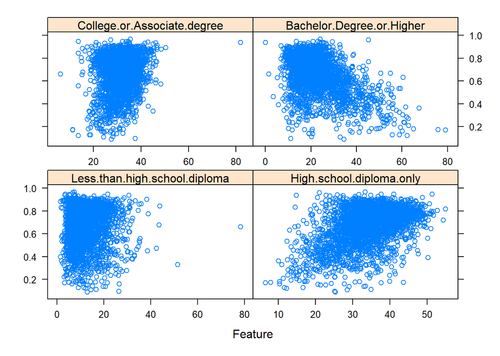

```r
featurePlot(x=df_merge_final[,c(2:5)],y=df_merge_final$Democrats.0.or.Republican.1)
```

Democrat counties have higher unemployment rate and population, differences in other attributes like poverty percentage, median household income, and rural or urban seem not apparent just by looking at feature plot

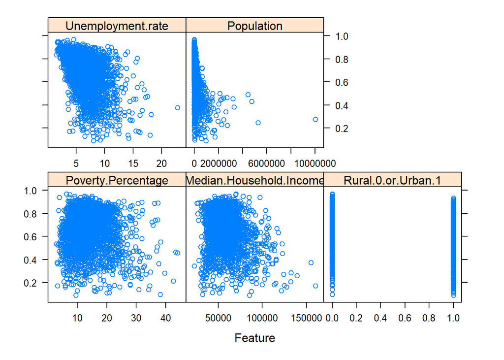

```r
featurePlot(x=df_merge_final[,c(6:10)],y=df_merge_final$Democrats.0.or.Republican.1)
```

##1.9 Use range to scale data

```r
transformer<-preProcess(df_merge_final,method='range')
df_merge_final_trans<-predict(transformer,df_merge_final)
head(df_merge_final_trans)
```

```
##   Democrats.0.or.Republican.1 Less.than.high.school.diploma
## 1                   0.4435259                    0.13836541
## 2                   0.2531423                    0.08402027
## 3                   0.5316987                    0.12479152
## 5                   0.3105828                    0.07562133
## 6                   0.8693898                    0.17809529
## 7                   0.7179320                    0.09969923
##   High.school.diploma.only College.or.Associate.degree
## 1                0.5531573                   0.3190214
## 2                0.4935366                   0.2519941
## 3                0.5011565                   0.3019197
## 5                0.2831227                   0.2970032
## 6                0.7281662                   0.3010256
## 7                0.4741969                   0.4089542
##   Bachelor.Degree.or.Higher Poverty.Percentage Median.Household.Income
## 1                 0.3097995          0.2444988               0.2811927
## 2                 0.4632641          0.1735941               0.3802218
## 3                 0.3711891          0.1955990               0.3415330
## 5                 0.5570326          0.3471883               0.2117406
## 6                 0.1814159          0.2396088               0.2810180
## 7                 0.3093795          0.2298289               0.2796935
##   Rural.0.or.Urban.1 Unemployment.rate  Population Party_REP
## 1                  1         0.3192488 0.018153385         0
## 2                  1         0.2816901 0.056986033         0
## 3                  1         0.2676056 0.023698353         1
## 5                  1         0.2018779 0.027801631         0
## 6                  1         0.1830986 0.002815574         1
## 7                  1         0.2300469 0.017490809         1
```

```r
df_merge_final_trans_1<-df_merge_final_trans[-c(1)]
```

##1.10 Split data into 70% for training set and 30% testing test

```r
set.seed(145)
train_part<-sample.split(df_merge_final_trans_1$Party_REP,SplitRatio = 0.7)
df_train<-subset(df_merge_final_trans_1,train_part==TRUE)
df_test<-subset(df_merge_final_trans_1,train_part==FALSE)
nrow(df_train)
```

```
## [1] 2128
```

```r
nrow(df_test)
```

```
## [1] 913
```

##1.11 Make target variable as factor

```r
df_train_final<-df_train
df_train_final$Party_REP<-as.factor(as.character(df_train_final$Party_REP))
head(df_train_final)
```

```
##    Less.than.high.school.diploma High.school.diploma.only
## 2                     0.08402027                0.4935366
## 6                     0.17809529                0.7281662
## 7                     0.09969923                0.4741969
## 9                     0.08348482                0.4166190
## 12                    0.10124290                0.5558142
## 14                    0.08489473                0.4781700
##    College.or.Associate.degree Bachelor.Degree.or.Higher Poverty.Percentage
## 2                    0.2519941                 0.4632641          0.1735941
## 6                    0.3010256                 0.1814159          0.2396088
## 7                    0.4089542                 0.3093795          0.2298289
## 9                    0.3773959                 0.3906065          0.1687042
## 12                   0.3639031                 0.3011301          0.1662592
## 14                   0.3994070                 0.3304586          0.1442543
##    Median.Household.Income Rural.0.or.Urban.1 Unemployment.rate  Population
## 2                0.3802218                  1         0.2816901 0.056986033
## 6                0.2810180                  1         0.1830986 0.002815574
## 7                0.2796935                  1         0.2300469 0.017490809
## 9                0.3127274                  1         0.2676056 0.060570335
## 12               0.2581220                  1         0.3004695 0.018652289
## 14               0.3611176                  1         0.2018779 0.021787717
##    Party_REP
## 2          0
## 6          1
## 7          1
## 9          1
## 12         1
## 14         1
```

#2. Run classification models ##2.1 Logistic Regression

```r
logis_reg_model<-glm(Party_REP~., data=df_train_final,family = "binomial")
options(scipen=999)
summary(logis_reg_model)
```

```
##
## Call:
## glm(formula = Party_REP ~ ., family = "binomial", data = df_train_final)
##
## Deviance Residuals:
##      Min        1Q    Median        3Q       Max
## -3.14956   0.08401   0.18246   0.34890   2.42711
##
## Coefficients:
##                                    Estimate    Std. Error z value
## (Intercept)                    5787585.7231  5265186.3379   1.099
## Less.than.high.school.diploma -5155916.8152  4690539.4903  -1.099
## High.school.diploma.only      -3254450.6163  2960705.5533  -1.099
## College.or.Associate.degree   -5098977.6651  4638741.7139  -1.099
## Bachelor.Degree.or.Higher     -5317215.0304  4837270.3612  -1.099
## Poverty.Percentage                 -10.0091        1.1610  -8.621
## Median.Household.Income             -1.8408        1.5449  -1.192
## Rural.0.or.Urban.1                  -0.3513        0.2133  -1.647
## Unemployment.rate                   -9.3394        0.9243 -10.105
## Population                         -25.5200        5.8482  -4.364
##                                           Pr(>|z|)
## (Intercept)                                 0.2717
## Less.than.high.school.diploma               0.2717
## High.school.diploma.only                    0.2717
## College.or.Associate.degree                 0.2717
## Bachelor.Degree.or.Higher                   0.2717
## Poverty.Percentage            < 0.0000000000000002 ***
## Median.Household.Income                     0.2334
## Rural.0.or.Urban.1                          0.0995 .
## Unemployment.rate             < 0.0000000000000002 ***
## Population                               0.0000128 ***
## ---
## Signif. codes:  0 '***' 0.001 '**' 0.01 '*' 0.05 '.' 0.1 ' ' 1
##
## (Dispersion parameter for binomial family taken to be 1)
##
##     Null deviance: 1859.65  on 2127  degrees of freedom
## Residual deviance:  946.24  on 2118  degrees of freedom
## AIC: 966.24
##
## Number of Fisher Scoring iterations: 6
```

```r
log_pred<-predict(logis_reg_model,df_test, type='response')
df_test$result<-log_pred
df_test$finalresult<-ifelse(df_test$result>=0.5,1,0)
head(df_test)
```

```
##    Less.than.high.school.diploma High.school.diploma.only
## 1                     0.13836541                0.5531573
## 3                     0.12479152                0.5011565
## 5                     0.07562133                0.2831227
## 8                     0.25609289                0.7220615
## 10                    0.11986985                0.4231685
## 11                    0.26953337                0.7386429
##    College.or.Associate.degree Bachelor.Degree.or.Higher Poverty.Percentage
## 1                    0.3190214                 0.3097995          0.2444988
## 3                    0.3019197                 0.3711891          0.1955990
## 5                    0.2970032                 0.5570326          0.3471883
## 8                    0.2797940                 0.1298808          0.3545232
## 10                   0.3072920                 0.4185432          0.1955990
## 11                   0.2716142                 0.1145434          0.4229829
##    Median.Household.Income Rural.0.or.Urban.1 Unemployment.rate  Population
## 1                0.2811927                  1         0.3192488 0.018153385
## 3                0.3415330                  1         0.2676056 0.023698353
## 5                0.2117406                  1         0.2018779 0.027801631
## 8                0.1845579                  0         0.2347418 0.002819968
## 10               0.2983901                  1         0.3802817 0.194160343
## 11               0.1535108                  0         0.1924883 0.001356508
##    Party_REP      result finalresult
## 1          0 0.830216850           1
## 3          1 0.809376203           1
## 5          0 0.114410602           0
## 8          1 0.991213671           1
## 10         0 0.008107562           0
## 11         1 0.990105768           1
```

```r
log_result<-confusionMatrix(as.factor(df_test$finalresult),as.factor(df_test$Party_REP))
print(log_result)
```

```
## Confusion Matrix and Statistics
##
##           Reference
## Prediction   0   1
##          0  89  30
##          1  56 738
##
##                Accuracy : 0.9058
##                  95% CI : (0.885, 0.924)
##     No Information Rate : 0.8412
##     P-Value [Acc > NIR] : 0.000000008344
##
##                   Kappa : 0.6198
##
##  Mcnemar's Test P-Value : 0.007022
##
##             Sensitivity : 0.61379
##             Specificity : 0.96094
##          Pos Pred Value : 0.74790
##          Neg Pred Value : 0.92947
##              Prevalence : 0.15882
##          Detection Rate : 0.09748
##    Detection Prevalence : 0.13034
##       Balanced Accuracy : 0.78737
##
##        'Positive' Class : 0
##
```

```r
df_test<-df_test[,-c(11:12)]
```

##2.2 Decision Tree

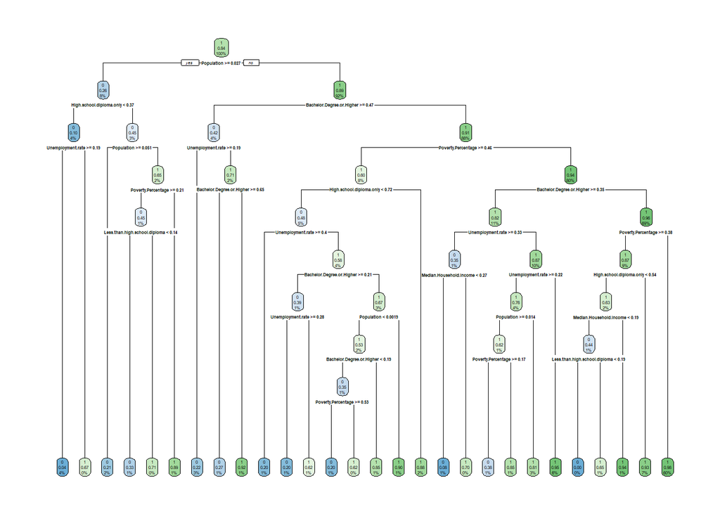

```r
tree_model<-rpart(Party_REP~., data=df_train_final, control = rpart.control(cp = 0.001))
rpart.plot(tree_model)
```

```r
tree_pred<-predict(tree_model,df_test)
```

```r
tree_pred_final <- ifelse(tree_pred[,c(2)]>=0.5,1,0)
tree_result<-confusionMatrix(as.factor(tree_pred_final),as.factor(df_test$Party_REP))
print(tree_result)
```

```
## Confusion Matrix and Statistics
##
##           Reference
## Prediction   0   1
##          0  78  44
##          1  67 724
##
##                Accuracy : 0.8784
##                  95% CI : (0.8554, 0.8989)
##     No Information Rate : 0.8412
##     P-Value [Acc > NIR] : 0.0008785
##
##                   Kappa : 0.5137
##
##  Mcnemar's Test P-Value : 0.0367845
##
##             Sensitivity : 0.53793
##             Specificity : 0.94271
##          Pos Pred Value : 0.63934
##          Neg Pred Value : 0.91530
##              Prevalence : 0.15882
##          Detection Rate : 0.08543
##    Detection Prevalence : 0.13363
##       Balanced Accuracy : 0.74032
##
##        'Positive' Class : 0
##
```

##2.3 Random Forest

```r
rf_model <- randomForest(Party_REP ~., data=df_train_final, importance=TRUE, proximity=TRUE)
```

```r
rf_pred <- predict(rf_model, df_test)
rf_result<-confusionMatrix(as.factor(rf_pred),as.factor(df_test$Party_REP))
print(rf_result)
```

```
## Confusion Matrix and Statistics
##
##           Reference
## Prediction   0   1
##          0  78  23
##          1  67 745
##
##                Accuracy : 0.9014
##                  95% CI : (0.8802, 0.92)
##     No Information Rate : 0.8412
##     P-Value [Acc > NIR] : 0.00000008539
##
##                   Kappa : 0.5793
##
##  Mcnemar's Test P-Value : 0.00000582626
##
##             Sensitivity : 0.53793
##             Specificity : 0.97005
##          Pos Pred Value : 0.77228
##          Neg Pred Value : 0.91749
##              Prevalence : 0.15882
##          Detection Rate : 0.08543
##    Detection Prevalence : 0.11062
##       Balanced Accuracy : 0.75399
##
##        'Positive' Class : 0
##
```

##2.4 AdaBoost

```r
ada_model <- ada(Party_REP~., data=df_train_final, type="gentle")
```

```r
ada_pred <- predict(ada_model, df_test)
ada_result <- confusionMatrix(as.factor(ada_pred),as.factor(df_test$Party_REP))
print(ada_result)
```

```
## Confusion Matrix and Statistics
##
##           Reference
## Prediction   0   1
##          0  80  36
##          1  65 732
##
##                Accuracy : 0.8894
##                  95% CI : (0.8672, 0.909)
##     No Information Rate : 0.8412
##     P-Value [Acc > NIR] : 0.00001948
##
##                   Kappa : 0.5494
##
##  Mcnemar's Test P-Value : 0.005335
##
##             Sensitivity : 0.55172
##             Specificity : 0.95312
##          Pos Pred Value : 0.68966
##          Neg Pred Value : 0.91844
##              Prevalence : 0.15882
##          Detection Rate : 0.08762
##    Detection Prevalence : 0.12705
##       Balanced Accuracy : 0.75242
##
##        'Positive' Class : 0
##
```

##2.5 XGBoost

```r
df_xgboost<-df_train_final
df_xgboost$Party_REP<-as.numeric(as.character(df_train_final$Party_REP))
df_xgboost1 <- df_xgboost[,-c(10)]
xgboost_model <- xgboost(data = as.matrix(df_xgboost1),label=df_xgboost$Party_REP, max.depth = 2, eta = 1, nthread = 2, nround =500, objective = "binary:logistic", verbose=0)
```

```r
xgboost_pred <- predict(xgboost_model, as.matrix(df_test[,-c(10)]))
xgboost_pred_final <- ifelse(xgboost_pred>=0.5,1,0)
xgboost_result <- confusionMatrix(as.factor(xgboost_pred_final), as.factor(df_test$Party_REP))
print(xgboost_result)
```

```
## Confusion Matrix and Statistics
##
##           Reference
## Prediction   0   1
##          0  81  47
##          1  64 721
##
##                Accuracy : 0.8784
##                  95% CI : (0.8554, 0.8989)
##     No Information Rate : 0.8412
##     P-Value [Acc > NIR] : 0.0008785
##
##                   Kappa : 0.5223
##
##  Mcnemar's Test P-Value : 0.1288499
##
##             Sensitivity : 0.55862
##             Specificity : 0.93880
##          Pos Pred Value : 0.63281
##          Neg Pred Value : 0.91847
##              Prevalence : 0.15882
##          Detection Rate : 0.08872
##    Detection Prevalence : 0.14020
##       Balanced Accuracy : 0.74871
##
##        'Positive' Class : 0
##
```

##2.6 Support Vector Machine - Linear

```r
svm_linear_model <- svm(Party_REP ~., data=df_train_final, kernel="linear")
```

```r
svm_linear_pred<-predict(svm_linear_model,df_test)
svm_linear_result<-confusionMatrix(as.factor(svm_linear_pred),as.factor(df_test$Party_REP))
print(svm_linear_result)
```

```
## Confusion Matrix and Statistics
##
##           Reference
## Prediction   0   1
##          0  85  24
##          1  60 744
##
##                Accuracy : 0.908
##                  95% CI : (0.8874, 0.926)
##     No Information Rate : 0.8412
##     P-Value [Acc > NIR] : 0.000000002421
##
##                   Kappa : 0.6171
##
##  Mcnemar's Test P-Value : 0.0001341
##
##             Sensitivity : 0.5862
##             Specificity : 0.9688
##          Pos Pred Value : 0.7798
##          Neg Pred Value : 0.9254
##              Prevalence : 0.1588
##          Detection Rate : 0.0931
##    Detection Prevalence : 0.1194
##       Balanced Accuracy : 0.7775
##
##        'Positive' Class : 0
##
```

##2.7 Support Vector Machine - RBF

```r
svm_rbf_model <- svm(Party_REP ~., data=df_train_final, kernel="radial")
```

```r
svm_rbf_pred<-predict(svm_rbf_model,df_test)
svm_rbf_result<-confusionMatrix(as.factor(svm_rbf_pred),as.factor(df_test$Party_REP))
print(svm_rbf_result)
```

```
## Confusion Matrix and Statistics
##
##           Reference
## Prediction   0   1
##          0  80  17
##          1  65 751
##
##                Accuracy : 0.9102
##                  95% CI : (0.8897, 0.9279)
##     No Information Rate : 0.8412
##     P-Value [Acc > NIR] : 0.0000000006672
##
##                   Kappa : 0.6117
##
##  Mcnemar's Test P-Value : 0.0000002099761
##
##             Sensitivity : 0.55172
##             Specificity : 0.97786
##          Pos Pred Value : 0.82474
##          Neg Pred Value : 0.92034
##              Prevalence : 0.15882
##          Detection Rate : 0.08762
##    Detection Prevalence : 0.10624
##       Balanced Accuracy : 0.76479
##
##        'Positive' Class : 0
##
```

##2.8 K-Nearest Neighbors

```r
knn_train_df <- df_train_final[,-c(10)]
knn_test_df <- df_test[,-c(10)]
knn_model1<-knn(train=knn_train_df, test=knn_test_df, cl=df_train_final$Party_REP, k = 25, prob=FALSE)
```

```r
knn_result<-confusionMatrix(as.factor(knn_model1), as.factor(df_test$Party_REP))
print(knn_result)
```

```
## Confusion Matrix and Statistics
##
##           Reference
## Prediction   0   1
##          0  68  16
##          1  77 752
##
##                Accuracy : 0.8981
##                  95% CI : (0.8767, 0.917)
##     No Information Rate : 0.8412
##     P-Value [Acc > NIR] : 0.0000004305658
##
##                   Kappa : 0.5403
##
##  Mcnemar's Test P-Value : 0.0000000004918
##
##             Sensitivity : 0.46897
##             Specificity : 0.97917
##          Pos Pred Value : 0.80952
##          Neg Pred Value : 0.90712
##              Prevalence : 0.15882
##          Detection Rate : 0.07448
##    Detection Prevalence : 0.09200
##       Balanced Accuracy : 0.72407
##
##        'Positive' Class : 0
##
```

##2.9 Neural Network

```r
nn_model <- neuralnet(Party_REP ~., data=df_train_final)
plot(nn_model)
```

```r
nn_pred <- predict(nn_model, df_test)
nn_pred_final <- ifelse(nn_pred[,2]>0.5,1,0)
nn_result<-confusionMatrix(as.factor(nn_pred_final),as.factor(df_test$Party_REP))
print(nn_result)
```

```
## Confusion Matrix and Statistics
##
##           Reference
## Prediction   0   1
##          0  89  30
##          1  56 738
##
##                Accuracy : 0.9058
##                  95% CI : (0.885, 0.924)
##     No Information Rate : 0.8412
##     P-Value [Acc > NIR] : 0.000000008344
##
##                   Kappa : 0.6198
##
##  Mcnemar's Test P-Value : 0.007022
##
##             Sensitivity : 0.61379
##             Specificity : 0.96094
##          Pos Pred Value : 0.74790
##          Neg Pred Value : 0.92947
##              Prevalence : 0.15882
##          Detection Rate : 0.09748
##    Detection Prevalence : 0.13034
##       Balanced Accuracy : 0.78737
##
##        'Positive' Class : 0
##
```

##2.10 Naive Bayes

```r
naive_bayes_model <- naiveBayes(Party_REP~., data=df_train_final)
```

```r
naive_bayes_pred <- predict(naive_bayes_model, df_test)
naive_bayes_result<-confusionMatrix(as.factor(naive_bayes_pred),as.factor(df_test$Party_REP))
print(naive_bayes_result)
```

```
## Confusion Matrix and Statistics
##
##           Reference
## Prediction   0   1
##          0  86  53
##          1  59 715
##
##                Accuracy : 0.8773
##                  95% CI : (0.8543, 0.8979)
##     No Information Rate : 0.8412
##     P-Value [Acc > NIR] : 0.001217
##
##                   Kappa : 0.533
##
##  Mcnemar's Test P-Value : 0.636602
##
##             Sensitivity : 0.59310
##             Specificity : 0.93099
##          Pos Pred Value : 0.61871
##          Neg Pred Value : 0.92377
##              Prevalence : 0.15882
##          Detection Rate : 0.09419
##    Detection Prevalence : 0.15225
##       Balanced Accuracy : 0.76205
##
##        'Positive' Class : 0
##
```

##2.11 Merge all the results together

```r
table_result<-cbind(log_result$byClass,tree_result$byClass,rf_result$byClass,ada_result$byClass,xgboost_result$byClass,svm_linear_result$byClass,svm_rbf_result$byClass,knn_result$byClass,nn_result$byClass,naive_bayes_result$byClass)
table_accuracy<-cbind(log_result$overall['Accuracy'],tree_result$overall['Accuracy'],rf_result$overall['Accuracy'],ada_result$overall['Accuracy'],xgboost_result$overall['Accuracy'],svm_linear_result$overall['Accuracy'],svm_rbf_result$overall['Accuracy'],knn_result$overall['Accuracy'],nn_result$overall['Accuracy'],naive_bayes_result$overall['Accuracy'])
table_final<-rbind(table_accuracy,table_result)
colnames(table_final)<-c('Logistic Regression','Decision Tree','Random Forest','Adaboost','Xgboost','SVM - Linear','SVM - RBF','KNN','Neural Net','Naive Bayes')
print(table_final)
```

```
##                      Logistic Regression Decision Tree Random Forest   Adaboost
## Accuracy                      0.90580504    0.87842278    0.90142388 0.88937568
## Sensitivity                   0.61379310    0.53793103    0.53793103 0.55172414
## Specificity                   0.96093750    0.94270833    0.97005208 0.95312500
## Pos Pred Value                0.74789916    0.63934426    0.77227723 0.68965517
## Neg Pred Value                0.92947103    0.91529709    0.91748768 0.91844417
## Precision                     0.74789916    0.63934426    0.77227723 0.68965517
## Recall                        0.61379310    0.53793103    0.53793103 0.55172414
## F1                            0.67424242    0.58426966    0.63414634 0.61302682
## Prevalence                    0.15881709    0.15881709    0.15881709 0.15881709
## Detection Rate                0.09748083    0.08543264    0.08543264 0.08762322
## Detection Prevalence          0.13033954    0.13362541    0.11062432 0.12705367
## Balanced Accuracy             0.78736530    0.74031968    0.75399156 0.75242457
##                         Xgboost SVM - Linear  SVM - RBF        KNN Neural Net
## Accuracy             0.87842278   0.90799562 0.91018620 0.89813801 0.90580504
## Sensitivity          0.55862069   0.58620690 0.55172414 0.46896552 0.61379310
## Specificity          0.93880208   0.96875000 0.97786458 0.97916667 0.96093750
## Pos Pred Value       0.63281250   0.77981651 0.82474227 0.80952381 0.74789916
## Neg Pred Value       0.91847134   0.92537313 0.92034314 0.90711701 0.92947103
## Precision            0.63281250   0.77981651 0.82474227 0.80952381 0.74789916
## Recall               0.55862069   0.58620690 0.55172414 0.46896552 0.61379310
## F1                   0.59340659   0.66929134 0.66115702 0.59388646 0.67424242
## Prevalence           0.15881709   0.15881709 0.15881709 0.15881709 0.15881709
## Detection Rate       0.08871851   0.09309967 0.08762322 0.07447974 0.09748083
## Detection Prevalence 0.14019715   0.11938664 0.10624315 0.09200438 0.13033954
## Balanced Accuracy    0.74871139   0.77747845 0.76479436 0.72406609 0.78736530
##                      Naive Bayes
## Accuracy              0.87732749
## Sensitivity           0.59310345
## Specificity           0.93098958
## Pos Pred Value        0.61870504
## Neg Pred Value        0.92377261
## Precision             0.61870504
## Recall                0.59310345
## F1                    0.60563380
## Prevalence            0.15881709
## Detection Rate        0.09419496
## Detection Prevalence  0.15224535
## Balanced Accuracy     0.76204652
```

##2.11.1 Transpose the result and order it by accuracy, sensitivity, specificity and balanced accuracy respectively

```r
transposed_table_final<-as.data.frame(t(table_final[c(1:3,12),]))
transposed_table_final[order(-transposed_table_final$Accuracy),]
```

```
##                      Accuracy Sensitivity Specificity Balanced Accuracy
## SVM - RBF           0.9101862   0.5517241   0.9778646         0.7647944
## SVM - Linear        0.9079956   0.5862069   0.9687500         0.7774784
## Logistic Regression 0.9058050   0.6137931   0.9609375         0.7873653
## Neural Net          0.9058050   0.6137931   0.9609375         0.7873653
## Random Forest       0.9014239   0.5379310   0.9700521         0.7539916
## KNN                 0.8981380   0.4689655   0.9791667         0.7240661
## Adaboost            0.8893757   0.5517241   0.9531250         0.7524246
## Decision Tree       0.8784228   0.5379310   0.9427083         0.7403197
## Xgboost             0.8784228   0.5586207   0.9388021         0.7487114
## Naive Bayes         0.8773275   0.5931034   0.9309896         0.7620465
```

```r
transposed_table_final[order(-transposed_table_final$Sensitivity),]
```

```
##                      Accuracy Sensitivity Specificity Balanced Accuracy
## Logistic Regression 0.9058050   0.6137931   0.9609375         0.7873653
## Neural Net          0.9058050   0.6137931   0.9609375         0.7873653
## Naive Bayes         0.8773275   0.5931034   0.9309896         0.7620465
## SVM - Linear        0.9079956   0.5862069   0.9687500         0.7774784
## Xgboost             0.8784228   0.5586207   0.9388021         0.7487114
## Adaboost            0.8893757   0.5517241   0.9531250         0.7524246
## SVM - RBF           0.9101862   0.5517241   0.9778646         0.7647944
## Decision Tree       0.8784228   0.5379310   0.9427083         0.7403197
## Random Forest       0.9014239   0.5379310   0.9700521         0.7539916
## KNN                 0.8981380   0.4689655   0.9791667         0.7240661
```

```r
transposed_table_final[order(-transposed_table_final$Specificity),]
```

```
##                      Accuracy Sensitivity Specificity Balanced Accuracy
## KNN                 0.8981380   0.4689655   0.9791667         0.7240661
## SVM - RBF           0.9101862   0.5517241   0.9778646         0.7647944
## Random Forest       0.9014239   0.5379310   0.9700521         0.7539916
## SVM - Linear        0.9079956   0.5862069   0.9687500         0.7774784
## Logistic Regression 0.9058050   0.6137931   0.9609375         0.7873653
## Neural Net          0.9058050   0.6137931   0.9609375         0.7873653
## Adaboost            0.8893757   0.5517241   0.9531250         0.7524246
## Decision Tree       0.8784228   0.5379310   0.9427083         0.7403197
## Xgboost             0.8784228   0.5586207   0.9388021         0.7487114
## Naive Bayes         0.8773275   0.5931034   0.9309896         0.7620465
```

```r
transposed_table_final[order(-transposed_table_final$`Balanced Accuracy`),]
```

```
##                      Accuracy Sensitivity Specificity Balanced Accuracy
## Logistic Regression 0.9058050   0.6137931   0.9609375         0.7873653
## Neural Net          0.9058050   0.6137931   0.9609375         0.7873653
## SVM - Linear        0.9079956   0.5862069   0.9687500         0.7774784
## SVM - RBF           0.9101862   0.5517241   0.9778646         0.7647944
## Naive Bayes         0.8773275   0.5931034   0.9309896         0.7620465
## Random Forest       0.9014239   0.5379310   0.9700521         0.7539916
## Adaboost            0.8893757   0.5517241   0.9531250         0.7524246
## Xgboost             0.8784228   0.5586207   0.9388021         0.7487114
## Decision Tree       0.8784228   0.5379310   0.9427083         0.7403197
## KNN                 0.8981380   0.4689655   0.9791667         0.7240661
```

From the tables above, accuracy ranged from 0.8773 (Naive Bayes) to 0.9102 (SVM - RBF), it shows accuracy of different methods are more or less the same. However, there is more differences in sensitivity and specificity. Sensitivity of all classification models are very low, with the highest are Logistic Regression (0.6138) and Neural Net (0.6138). Other methods like KNN (0.4690) and Decision Tree (0.5379) has much lower sensitivity.  
For specificity, the models has specificity in a range of 0.9310 to 0.9792, with KNN has the highest value. In the mean time, Naive Bayes and tree-based methods like decision tree, XGBoost have lesser value. The result show that, as the data is imbalanced to Republicans, most methods can achieve good results in predicting Republican win counties (Specificity)–that means identifying majority class than minority class. However, KNN, Random Forest and Decision Tree perform particularly worse in identifying Democrat win counties (Sensitivity). For our analysis, since we want to correctly classify both democrat win and republican win result (thus sensitivity and specificity is also important, in contrast to some other business analysis which need to maximize chance of getting true positive, e.g. identifying loan default), it is important to choose a classification method that perform well in both sensitivity and specificity. Therefore, Logistic Regression and Neural Net, which has best balanced accuracy, would be considered the best in our analysis.